# GeneAnnotation

# Chapter One: Generative Models for Discrete Data

```r
#for one value
dpois(x = 3, lambda = 5)
```

```
## [1] 0.1403739
```

```r
#for several values instead of a loop
dpois(x = 0:12, lambda = 5)
```

```
##  [1] 0.006737947 0.033689735 0.084224337 0.140373896 0.175467370 0.175467370
##  [7] 0.146222808 0.104444863 0.065278039 0.036265577 0.018132789 0.008242177
## [13] 0.003434240
```

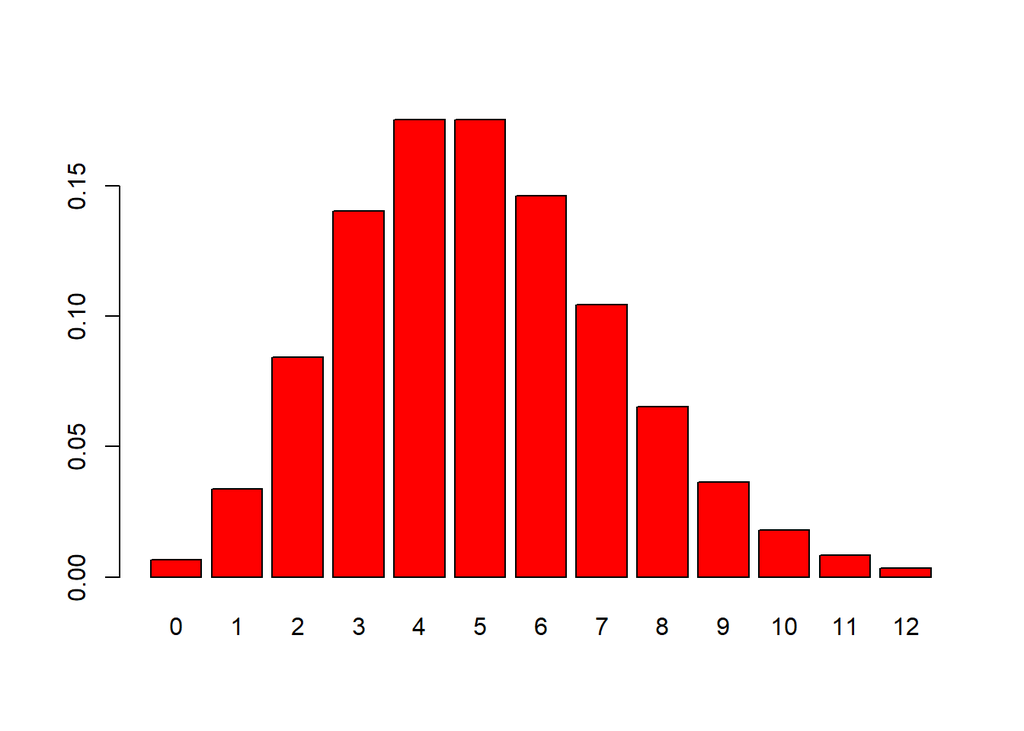

```r
barplot(dpois(0:12, 5), names.arg = 0:12, col = "red")
```

The Second code shows the probability for 0-12 mutations after one replication cycle in a barplot.

## Using discrete probability models

```r
genotype = c("AA","AO","BB","AO","OO","AO","AA","BO","BO","AO","BB","AO","BO","AB","OO","AB","BB","AO","AO")
table(genotype)
```

```
## genotype
## AA AB AO BB BO OO
##  2  2  7  3  3  2
```

```r
#with factor:
genotypeF =  factor(genotype)
levels(genotypeF)
```

```
## [1] "AA" "AB" "AO" "BB" "BO" "OO"
```

```r
table(genotypeF)
```

```
## genotypeF
## AA AB AO BB BO OO
##  2  2  7  3  3  2
```

with factors, R automatically detects all the layers of a function and encodes the categorial variables. Levels define which values are allowed in a set of data.

### Bernoulli trials

```r
# r-functions generate tailored outcomes for each type of distribution
rbinom(15, prob = 0.5, size = 1)
```

```
##  [1] 0 1 0 0 0 1 0 1 0 1 1 1 0 1 0
```

```r
# withs unequal probabilities
rbinom(12, prob = 2/3, size = 1)
```

```
##  [1] 1 1 0 1 1 1 1 1 1 1 1 1
```

**Parameters:** Number of Trials, probability of success, repetitions per trial

This code chunk represents binomial experiment. The first a coin toss with equal probability of head and tail, the second one a ball drop into boxes with different sizes and therefore unequal probabilities.

```r
#with changed parameters
rbinom(1, prob = 2/3, size = 12)
```

```
## [1] 8
```

**Parameters**: Number of successes, probability of success, Number of Trials

This command counts the number of successful events in the same experiment as the second above (with the unequal probabilities). The number of unsuccessful events can be calculated as Number of Trials - Number of successes.

### Binomial success counts

```r
set.seed(235569515)
rbinom(1, prob = 0.3, size = 15)
```

```
## [1] 5
```

`set.seed` determines a starting point for the trials, so that the outcome always stays the same. This is important to reproduce experiments (reliability).

```r
probabilities = dbinom(0:15, prob = 0.3, size = 15)
round(probabilities, 2)
```

```
##  [1] 0.00 0.03 0.09 0.17 0.22 0.21 0.15 0.08 0.03 0.01 0.00 0.00 0.00 0.00 0.00
## [16] 0.00
```

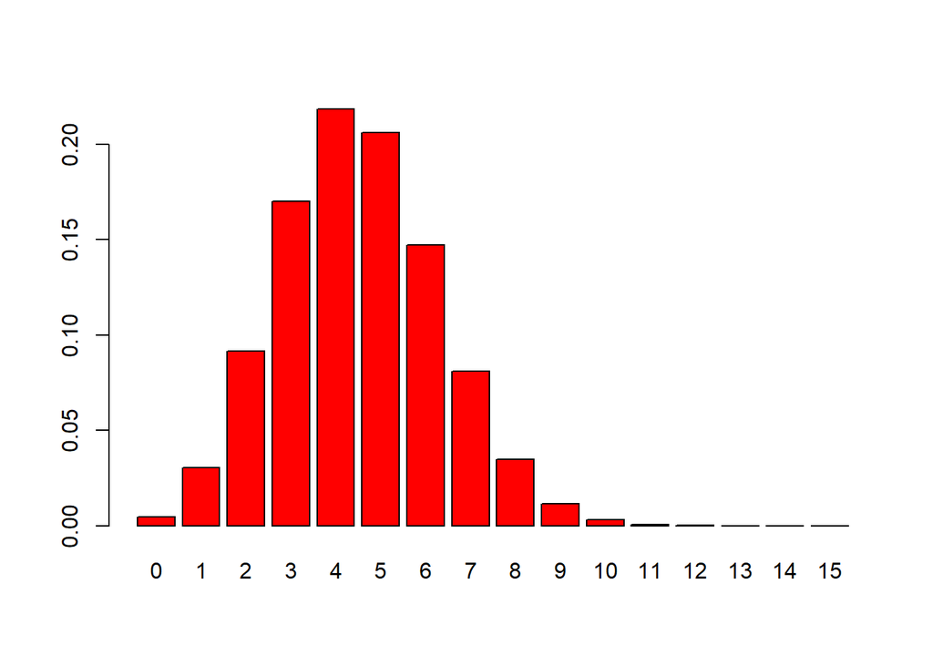

```r
barplot(probabilities, names.arg = 0:15, col = "red")
```

`round()`controls the number of printed decimal digits `names.arg`Labels the x-axis bars with the possible event outcomes

### Poisson distributions

```r
rbinom(1, prob = 5e-4, size = 10000)
```

```
## [1] 6
```

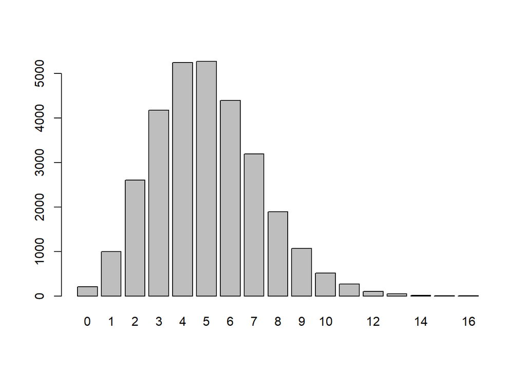

```r
simulations = rbinom(n = 30000, prob = 5e-4, size = 10000)
barplot(table(simulations), sol = "lavender")
```

using the poisson distribution, when Number of trials is large and the probability of success is small. The Parameter is Lambda

### A generative model for epitope detection

```r
load("../data/e100.RData")
barplot(e100, ylim = c(0, 7), width = 0.7, xlim = c(-0.5, 100.5),
  names.arg = seq_along(e100), col = "darkolivegreen")
```

[output not shown]

**Parameter:** e100: data which is plotted ylim: sets y-axis width: width of the bars xlim: setzs x-axis names.arg = seq_along(e100): generates Numbers from 1 to 100 and labels the x-axis

```r
1 - ppois(6, 0.5)
```

```
## [1] 1.00238e-06
```

```r
ppois(6, 0.5, lower.tail = FALSE)
```

```
## [1] 1.00238e-06
```

Both commands yield the same result. ppois(x, lambda) calculates the probability of x or fewer results. By setting lower.tail = FALSE, the command calculates the probability for strictly more than x results (P(X > x)).

```r
maxes = replicate(100000, {
  max(rpois(100, 0.5))
})
table(maxes)
```

```
## maxes
##     1     2     3     4     5     6     7     9
##     7 23079 60787 14378  1595   138    15     1
```

**Parameter:** replicate(x, {}): replicates the code inside x-times max(rpois(100, 0.5)): takes the maximal value of 100 Poisson distributed numbers This simulation shows the distribution of the maximum number of mutations found in groups of 100 viruses. While the average is low (0.5), observing 3 or 4 mutations as a group maximum is very common.

## Multinomial distribution: the case of DNA

```r
pvec = rep(1/4, 4)
t(rmultinom(1, prob = pvec, size = 8)) #rmultinom simulates categorical data
```

```
##      [,1] [,2] [,3] [,4]
## [1,]    4    2    1    1
```

**Parameters:** 1/4: probability for success for each outcome 4: number of replications rmultinom(n, prob, size): n = number of independent simulations, prob = vector of probabilities (chance of each category), size = number of observations in each simulation 1: number of vectors to generate size: number if events pvec creates a vector with the results of the multinomial distribution t() transponses (flips) a matrix or dataframe

### Simulating for power

```r
obsunder0 = rmultinom(1000, prob = pvec, size = 20)
dim(obsunder0)
```

```
## [1]    4 1000
```

```r
expected0 = pvec * 20
sum((obsunder0[, 1] - expected0)^2 / expected0)
```

```
## [1] 1.2
```

dim() returns the rows and columns of a matrix expected0: calculates the expected value obsunder0[, n] - expected0: calculates the difference between the observed and expected value of all rows in the column n / expected0: standardization

```r
stat = function(obsvd, exptd = 20 * pvec) {
  sum((obsvd - exptd)^2 / exptd)
}
stat(obsunder0[, 1])
```

```
## [1] 1.2
```

```r
S0 = apply(obsunder0, 2, stat)
summary(S0)
```

```
##    Min. 1st Qu.  Median    Mean 3rd Qu.    Max.
##   0.000   1.200   2.800   2.941   4.000  22.000
```

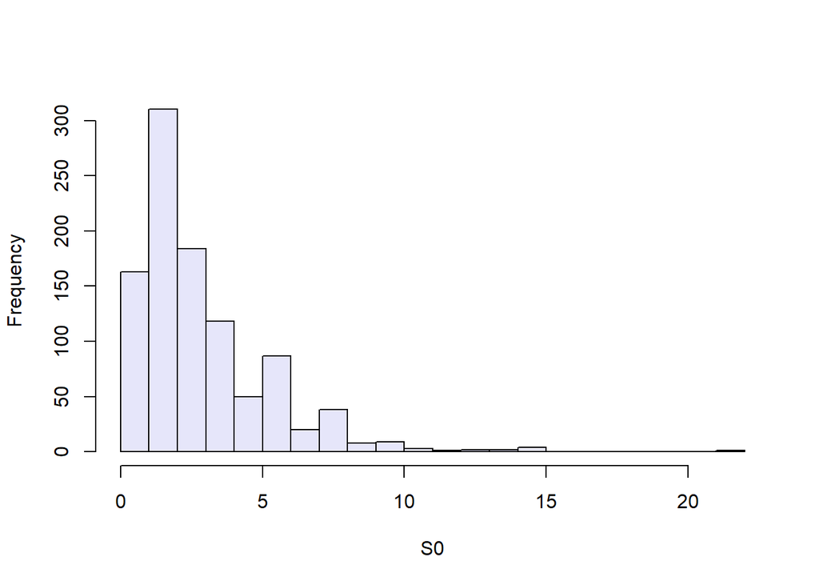

```r
hist(S0, breaks = 25, col = "lavender", main = "")
```

```r
q95 = quantile(S0, probs = 0.95)
q95
```

```
## 95%
## 7.6
```

apply(x, MARGIN, FUN): x = data source; MARGIN = direction (1 = rows, 2 = columns); FUN = applied function summary(): shows statistical indicators of the function hist(x, breaks, col, main): x = dataset, breaks = number of columns, col = folour, main = title quantile(x, probs): x = numeric vector whose quantiles are wanted (dataset); probs = numeric vector of probabilities [0, 1]

```r
pvecA = c(3/8, 1/4, 1/4, 1/8)
observed = rmultinom(1000, prob = pvecA, size = 20)
dim(observed)
```

```
## [1]    4 1000
```

```r
apply(observed, 1, mean)
```

```
## [1] 7.482 4.966 5.009 2.543
```

```r
expectedA = pvecA * 20
expectedA
```

```
## [1] 7.5 5.0 5.0 2.5
```

```r
stat(observed[, 1])
```

```
## [1] 3.6
```

```r
S1 = apply(observed, 2, stat)
q95
```

```
## 95%
## 7.6
```

```r
sum(S1 > q95) #counts the successes of the simulation
```

```
## [1] 206
```

```r
power = mean(S1 > q95) #the proportion of simulations where the test statistic exceeded the critical value
power
```

```
## [1] 0.206
```

An alternative Hypothesis for pvec, so calculation of power can be made The same structur than before, just with power analysis at the end sum(…, na.rm): … = numeric, complex or logical vector, na.rm = should missing values be removed? (default = FALSE) mean(x, na.rm, trim): x = the object (numerical or logical vector), na.rm = should missing values be removed? (default = FALSE), trim = cuts off data at the extreme of x (remove outliers)

# Chapter two: Statistical Modeling

## A simple example of statistial modeling

```r
rootogram() # diagnostic plot to evaluate the goodness of fit for probability models - has  lots of different parameters
prod() # returns the product of all the values present in its arguments
abline()
goodfit() #Check how well your observed data fit a theoretical probability distribution (such as the Poisson or Binomial distribution)
```

- prod(…, na.rm): … = numeric, complex or logical parameter, na.rm = should missing values be removed?
- abline(a, b, v, h, coef, …, untf): a = intercept, b = slope, v = x-values for vertical lines, h = y-values for horizontal lines, coef = a vector of length two giving the intercept and slope, … = graphical parameters (col, lwd), untf = wether ignore the transformation of the axis for visualization
- goodfit(x, type, method): x = data, type = distribution to check the data, method = a character string indicating whether the distribution should be fit via ML (Maximum Likelihood) or Minimum Chi-squared.

### Likelihood for the binomial distribution

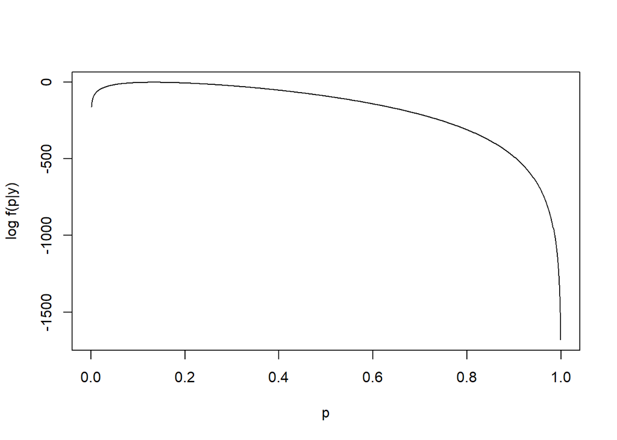

```r
loglikelihood = function(p, n = 300, y = 40) {
  log(choose(n, y)) + y * log(p) + (n - y) * log(1 - p)
}
p_seq = seq(0, 1, by = 0.001)
plot(p_seq, loglikelihood(p_seq), xlab = "p", ylab = "log f(p|y)", type = "l")
```

An example to plot the likelihood for an binomial distribution with an maximum around 0.1333, and a flat curve at the maximum, so other values of p are almost equally likely

## More Boxes: multinomial data

```r
# package "Biostrings" necessary (library("Biostrings"))
letterFrequency() # count occurrences of letters in biological sequence
vapply() #
rowMeans() # Form row sums and means for numeric arrays
colSums() # Form row and column sums and means for numeric arrays (or data frames)
round() # rounds the values in its first argument to the specified number of decimal places (default 0)
outer() # apply an operation to every possible combination of elements from two different arrays (here: Calculates the Expected Counts for the Chi-square test)
```

- letterFrequency(x, letters, OR, as.prob, threshold, ambiguityMap): x = String/ StringSet/ StringViews/ MaskedString, letters = character vector with ““, OR = wie mit Mehrdeutigkeit umgegangen wird (0 -> jeder einzeln,”|” -> Gruppen bilden), as.prob = relative number between [0, 1] instead of absolut numbers, threshold = sets minimal value for counting, ambiguityMap = tells how to deal with fuzzy letters if DNASequancing isn`t clean
- vapply(x, FUN, FUN.VALUE, …): x = vector, FUN = applied function, FUN.VALUE = generalized vector, … = optional arguments for FUN)
- rowMeans(x, dims): x = array of two or more dimensions (logical, numeric, complex, integer values), dims = Which dimensions are regarded as rows or columns to sum over
- colSums(x, dims): x = array of two or more dimensions, containing numeric, complex, integer or logical values, or a numeric data frame, dims = integer: Which dimensions are regarded as ‘rows’ or ‘columns’ to sum over
- round(x, digits): x = a numeric vector, digits = the number of decimal places you want to keep
- outer(X, Y, FUN, …): X and Y = first and second argument (mostly vector or array), FUN = a function to use on the outer products, … = optional arguments passed to FUN

```r
qqplot() # Produces a QQ-Plot
abline() # creates a line in a plot
chisq.test() # performs chi-squared contingency table tests and goodness-of-fit tests
```

- qqplot(x, y, asp, cex, pch): x numeric vector of observations, y = optional numeric vector of observations, asp = Aspect Rati0 (1 unit on x-axis = 1 unit on y-axis), cex = size of dots, pch = dots as solid circles
- abline(a, b, col): a = the y-intercept, b = the slope, col = colour of the line
- chisq.test(x, y, correct, p): x = numeric vector or matrix, y = a numeric vector; ignored if x is a matrix. If x is a factor, y should be a factor of the same length, correct = a logical indicating whether to apply continuity correction, p = a vector of probabilities of the same length of ‘x’

```r
HWTernaryPlot() # draws a ternary plot for three-way genotypic compositions (AA,AB,BB), and represents the acceptance region for different tests for Hardy-Weinberg equilibrium (HWE) in the plot

# library("seqLogo")
seqLogo() # The function produces a sequence logo plot based on the contained sequences
```

- HWTernaryPlot(X, markerlab, alpha, curvecols, mcex, vertex.cex): X = a matrix of n genotypic compositions or counts, markerlab = labels for the markers in the triangle, alpha = significance-level (default = 0.05), curvecols = a vector with four colour specifications for the different curves that can be used to delimit the HW acceptance region, mcex = character expansion factor for the labels of the markers, vertex.cex = character expansion factor for the labels of the vertices
- seqLogo(pwm, ic.scale, base_scale): pwm = data (position weigth matrix with the four bases), ic.scale = If TRUE, the total height of one column is proportional to the information content at that position, base_scale = adjust the width of the letters

### Nucleotide pattern in a genome

```r
countPattern() # count the frequency of a pattern
matchPattern() # finding all the occurrences of a given pattern (how many & where) -> more powerful
available.genomes # (package "BSgenome") search engine or catalog for pre-packaged, full-genome sequences available on the Bioconductor servers
expplot() # create an exponential probability plot
```

- countPattern(pattern, subject, max.mismatich): pattern = sequence we look for, Sequence in which we search, max.mismatch = how many mismatches in a pattern are allowed (0 = identity)
- matchPattern(pattern, subject, max.mismatch, with.indels): pattern = sequence we look for, Sequence in which we search, max.mismatch = how many mismatches in a pattern are allowed (0 = identity), with.indel = indels are allowed available.genomes(pattern, type, splitName, biocuv): pattern: filter results, type = specifies the type of genome package, splitName = returns a data frame where the package name is broken down into parts (Provider, Species, Release), making it much easier to read, biocuv = Allows you to check for genomes compatible with a specific Bioconductor version
- expplot(x, rate, labels): x = test data, rate = the rate lambda is the inverse of the mean (1/mu), labels = Adds the label “fit” to the reference line on the plot

### Modeling in the case of dependencies

**handle genomic coordinates (Bioconductor’s core infrastructure)**

```r
read.table() # Reads a file in table format and creates a data frame from it
with() # refer to columns in a data frame without typing the name of the data frame every single time
IRanges() # creates an object that stores simple intervals (start and end points on a number line)
GRanges() # takes those intervals and places them onto a specific biological map
views() #Pairs coordinates with the actual DNA sequence string
```

- read.table(file, header, sep, dec, skip, nrows): file = path to file, header = Set this to TRUE if the first row of your file contains the column names, sep = tells R how columns are divided (“” -> white space; “,” -> csv files, “ -> tab-seperated files), dec = decmial point character (instead of comma), skip = number of lines to ignore at the beginning of the file before it starts reading data, nrows = limits the number of rows to read
- IRanges(start, end, width): start = beginning position of the feature, end = ending position, width = start + width instead start + end
- GRanges(seqnames, ranges, strand, genome):seqname = chromosome name, ranges = IRanges object, strand = direction of the DNA (“+”, “-”, “*“), genome = version of the assembly
- views(subject, ranges): subject = full DNA sequence, ranges = IRanges coordinates to look at

```r
IdeogramTrack() # (package "Gvis")creates a visual representation of a chromosome, showing its cytogenetic bands (the light and dark patterns) and your current location
plotTracks() # (package "Gvis") Draws "Browser" style tracks (like the UCSC Genome Browser)
as() #core R function used for coercion, which means forcing an object from one class (type) into another
rowSums() #calculate the totals for each row in a numeric matrix or data frame
```

- IdeogramTrak(genome, chromosome, name, showId): genome = assembly version, chromosome = chromosome to display, name = label on the side of the plot, showId = shows chromosome name [TRUE/ FALSE]
- plotTracks(trackList, from/ to): trackList = list of track objects, from/ to = genomic range to display on the x-axis
- as(object, Class): object = data you currently have, Class = target format
- rowSums(x, na.rm, dims): x = numeric array, matrix, data frame, na.rm = ignore missing values?, dims = which dimension in a multidimensional array

```r
alphabetFrequency() # count the occurrences of every letter in the DNA alphabet
ncol() # returns the number of columns
pmax() # compares vector element-wise and returns the maximum
```

- alphabetFrequency(x, as.prob. baseOnly): x = input sequence, as.prob = returne relative frequencies, baseOnly = only counts A, C, G, T and the rest in “other”
- ncol(x): x = matrix or data frame
- pmax(…): … = two or more vectors